# Lista 4

# 4 Como geoms transformam os dados

Podemos fazer um gráfico de barras apenas chamando a função geom_bar

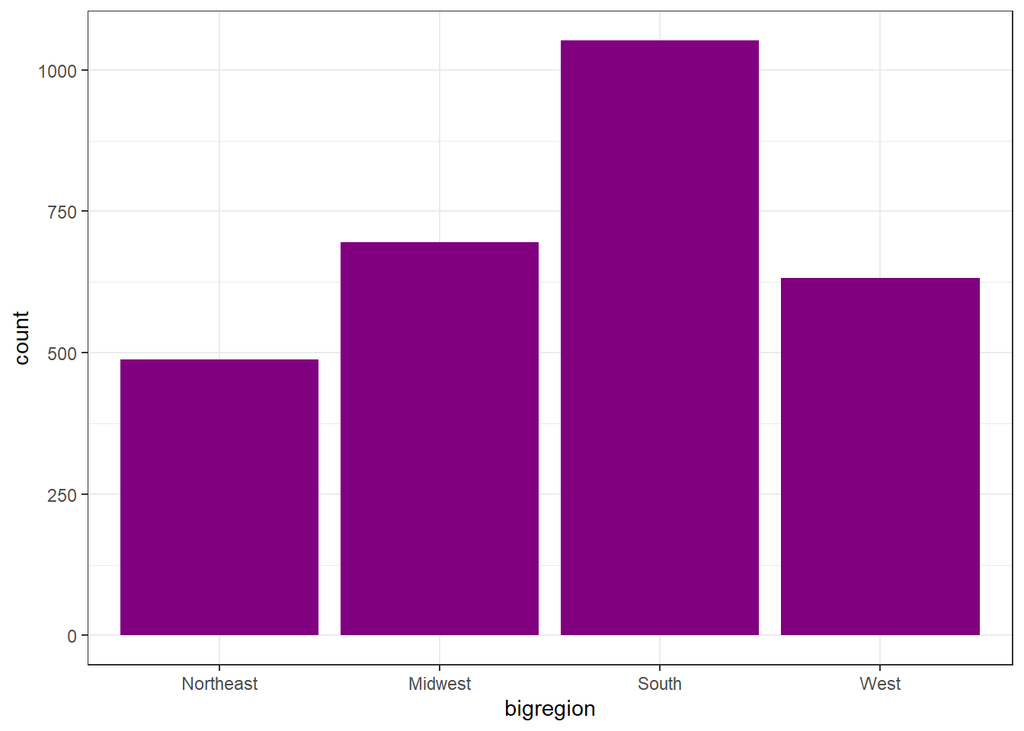

```r
p_2  <- ggplot(data = gss_sm, aes(x=bigregion))
p_2 +
  geom_bar(fill = "#800080") +
  theme_bw()
```

Note que foi cirada uma variável para o eixo y, mesmo que não dissemos para o R fazer isso. Isso acontece pois a função geom_bar já tem como parte dela em contar o número de ocorrências de uma determinada classe. Vamos supor agora, que queremos a frequência relativa de determinadas classes. Para isso, é preciso adicionar uma variável em geom_bar.

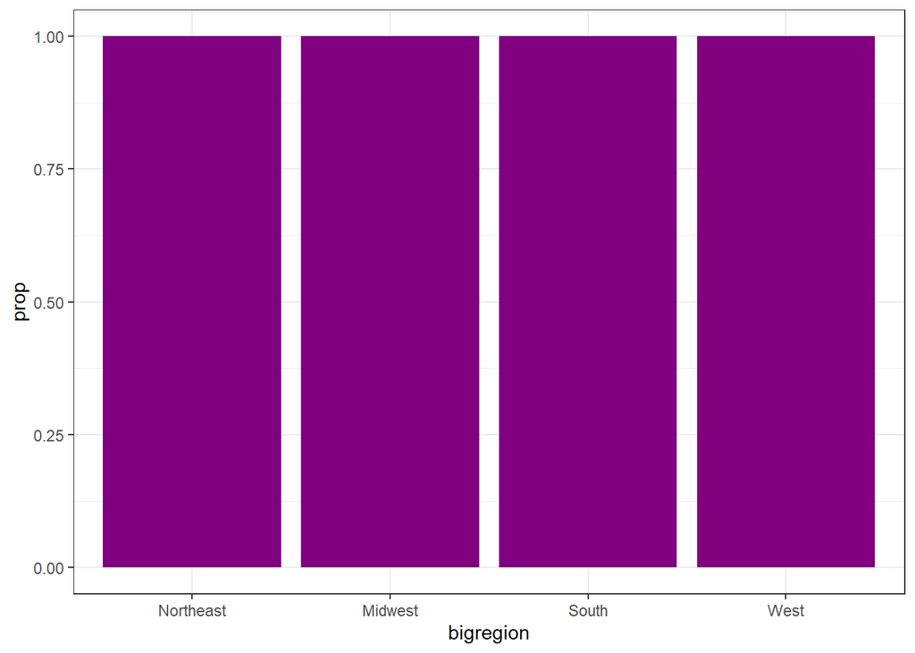

```r
p_2 + geom_bar(aes(y = after_stat(prop)), fill = "#800080") + theme_bw()
```

Note que ele ainda não produziu o gráfico que queremos, pois queremos que a soma de todas as porcentagens seja 1, ou seja, que ele interprete cada coluna como parte de um todo e não como o todo. Para isso, vamos “adicionar” uma coluna apenas para ele entender que deve contar todos como um grupo apenas

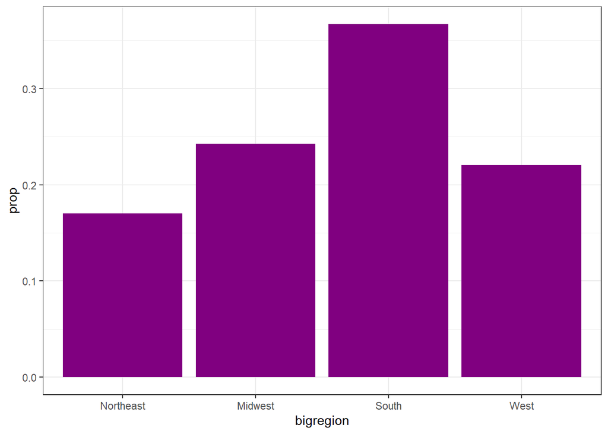

```r
p_2 + geom_bar(aes(y = after_stat(prop), group = 1,), fill = "#800080") + theme_bw()
```

Podemos também querer colorir os retângulos de nossa figura. Isso deve ser feito com a variável fill, pois a variável colour vai nos gerar um output diferente do esperado.

```r
table(gss_sm$religion)
```

```
##
## Protestant   Catholic     Jewish       None      Other
##       1371        649         51        619        159
```

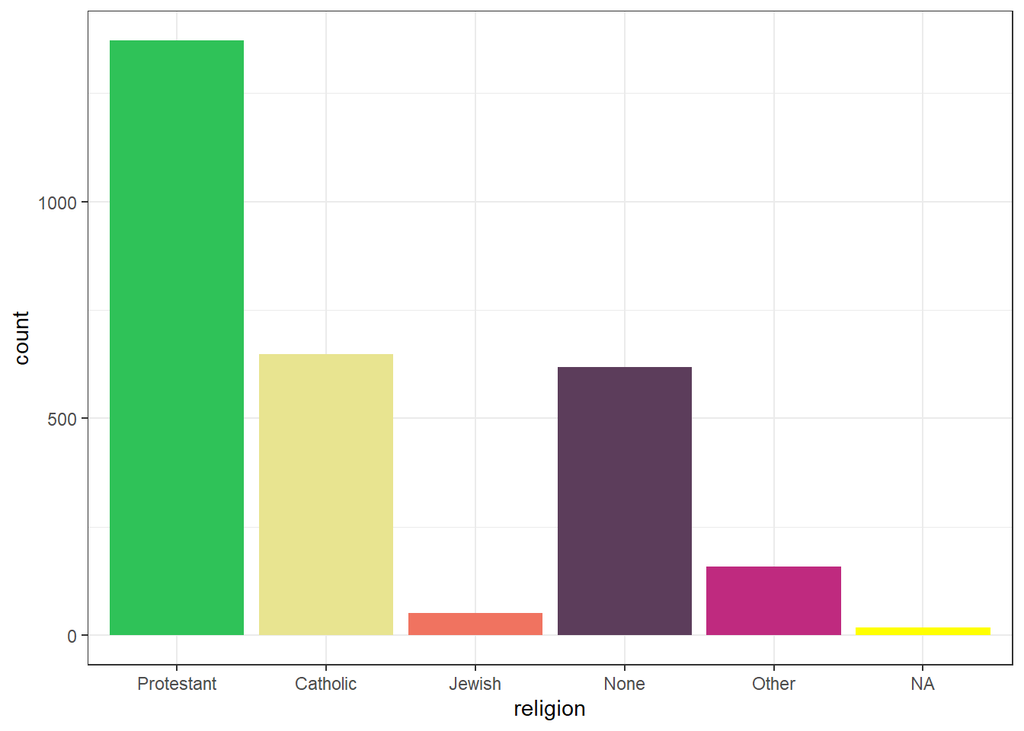

```r
cores <- c("#2fc258", "#e8e490", "#f07360", "#5c3d5b", "#bf2a7f", "yellow")
p_3 <- ggplot(data = gss_sm, mapping = aes(x = religion, fill = religion))
p_3 + geom_bar(fill = cores) + theme_bw()
```

Supondo agora que queremos saber como é a distribuição da religião por todas as regiões, percentualmente, podemos fazer isso com:

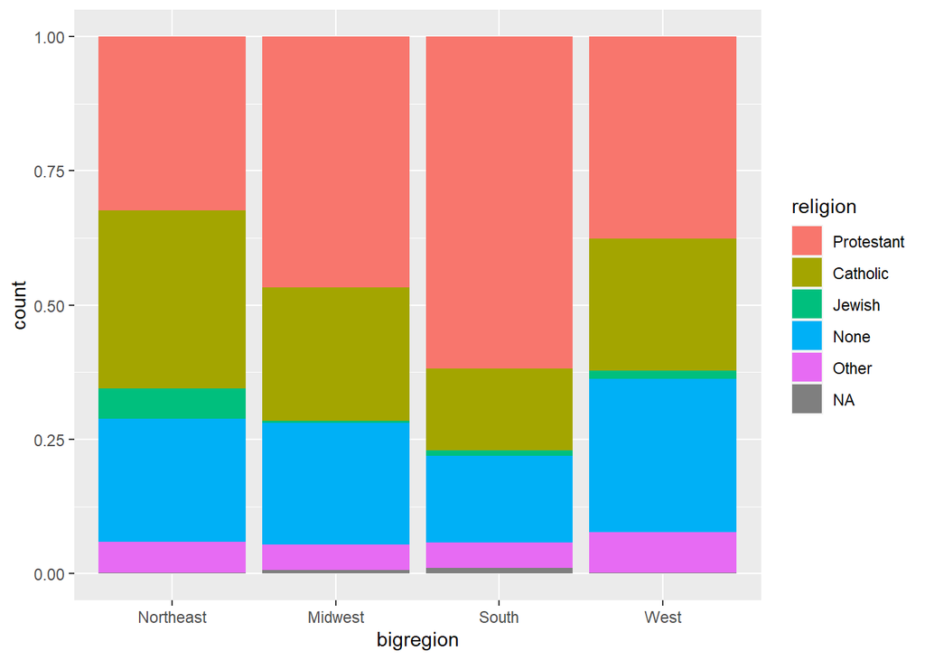

```r
p_4 <-  ggplot(data = gss_sm,
               mapping = aes(x = bigregion,
                             fill = religion))
p_4 +
  geom_bar(position = "fill")
```

Apesar de a visualização já nos entregar um ótimo dado, vamos supor que queremos esse mesmo dado, mas com as proporções uma do lado da outra. Do modo como os dados estão organizados apenas a função geom_bar não vai conseguir produzir esse tipo de gráfico. Vamos assim, facetar nosso gráfico por região e assim utilizar o geom_bar para plotar. Temos assim:

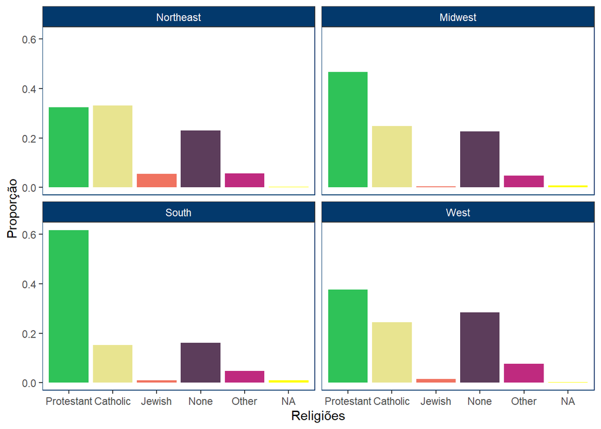

```r
cores_x4=c(cores, cores, cores, cores)
p_5 <- ggplot(data = gss_sm, mapping = aes(x = religion))
p_5 + geom_bar(fill = cores_x4, position = "dodge",
               mapping = aes(y = after_stat(prop),
                             group = bigregion)) +
  facet_wrap(~bigregion, ncol = 2) +
  theme_bw() +
  scale_y_continuous() +
  theme(strip.background = element_rect(fill ="#03396c"),
        strip.text = element_text(color = "white"),
        panel.border = element_rect(color = "#03396c", fill = NA),
        panel.grid = element_blank()) +
  labs(x = "Religiões", y = "Proporção")
```

# 5 Histogramas

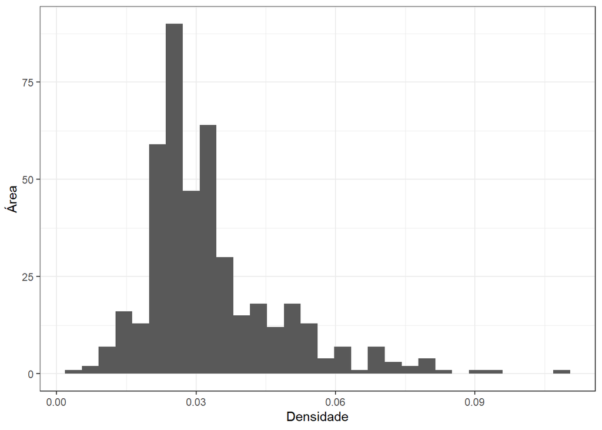

```r
p_6 <- ggplot(midwest, aes(x=area))
p_6 + geom_histogram() + theme_bw() + labs(x = "Densidade", y = "Área")
```

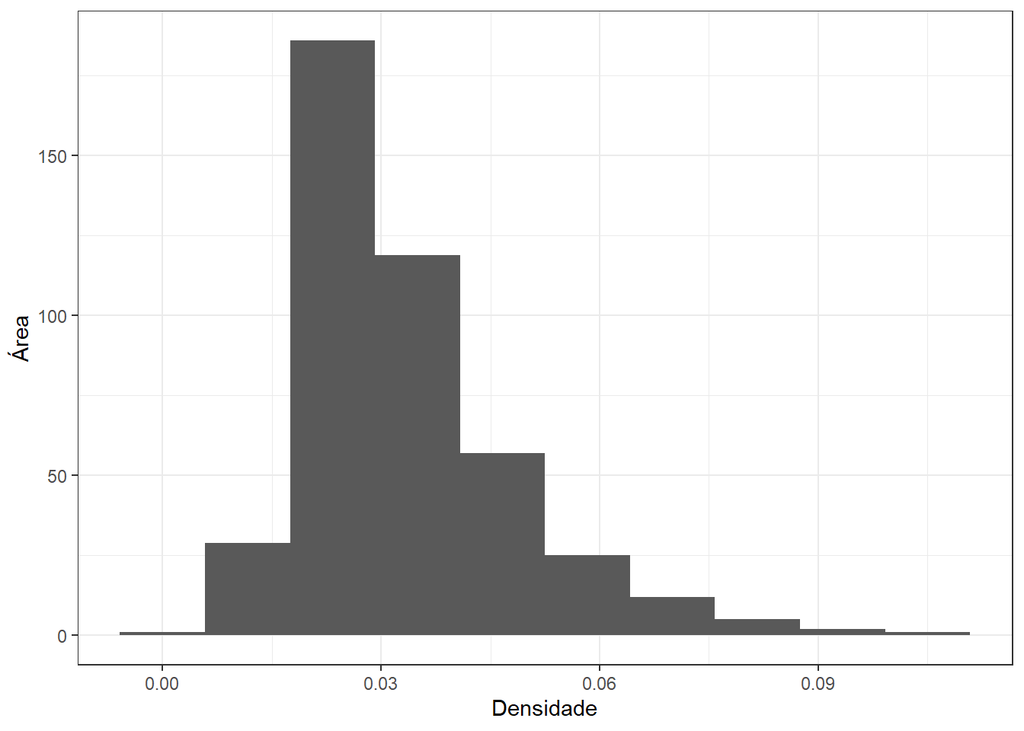

```r
p_6 + geom_histogram(bins = 10) + theme_bw() + labs(x = "Densidade", y = "Área")
```

Podemos juntar histogramas também, concatenando algumas strings

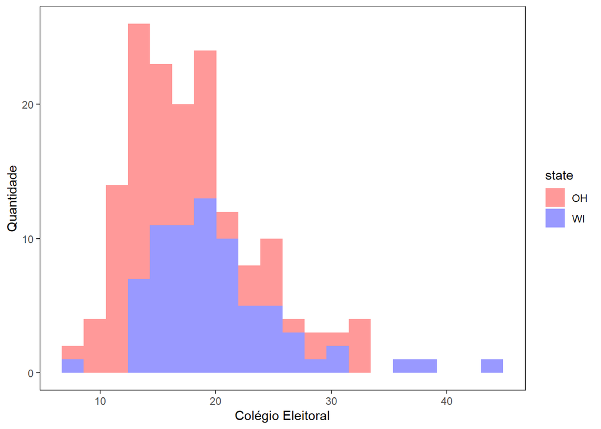

```r
oh_wi <- c("OH", "WI")
p_7 <- ggplot(data = subset(midwest,
                            subset = state %in% oh_wi),
              mapping = aes(x = percollege,
                            fill = state))
p_7 +
  geom_histogram(alpha = 0.4, bins = 20) +
  scale_fill_manual(values = c("red", "blue"))+
  theme_bw() +
  labs(y = "Quantidade", x = "Colégio Eleitoral") +
  theme(panel.grid = element_blank())
```

Podemos também fazer um histograma para variáveis contínuas.

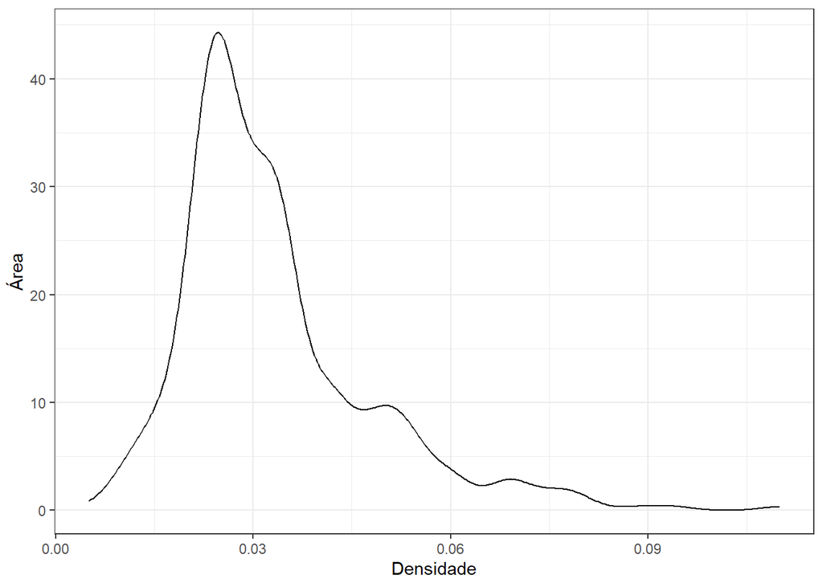

```r
p_8 <- ggplot(data = midwest,  mapping = aes(x= area))
p_8 + geom_density() + theme_bw() + labs(x = "Densidade", y = "Área")
```

Mas podemos colocar cores nas coisas

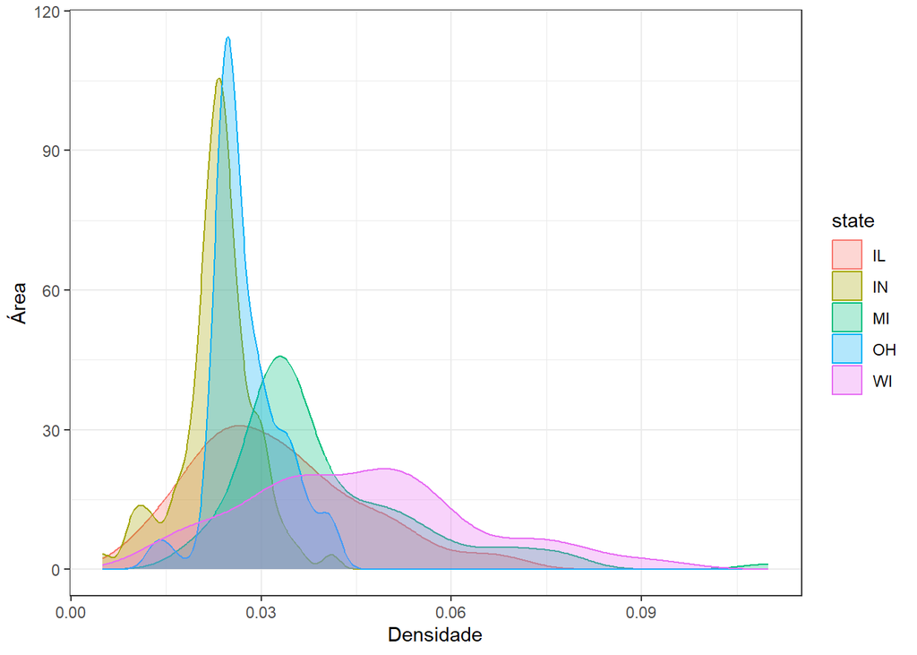

```r
p_9 <- ggplot(data = midwest, mapping = aes(x = area, fill = state, color = state))
p_9 + geom_density(alpha = 0.3) + theme_bw() + labs(x = "Densidade", y = "Área")
```

Mas note que muitas sobreposições fazem o nosso gráfico ficar muito poluído. Podemos filtrar assim um pouco da informação para deixar o gráfico um pouco mais apresentável.

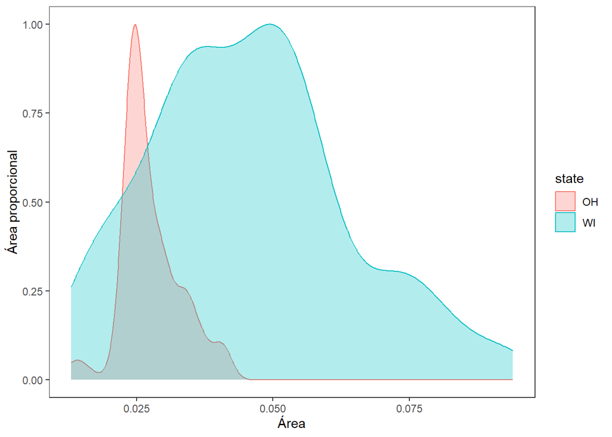

```r
p_10 <- ggplot(data = subset(midwest, subset = state %in% oh_wi),
              mapping = aes(x = area, fill = state, color = state))
p_10 +
  geom_density(alpha = 0.3,
               mapping = aes( y = after_stat(scaled))) +
  theme_bw() +
  labs(x = "Área", y = "Área proporcional") +
  theme(panel.grid = element_blank())
```

# 6 Evitando Transformações

Note que quando usamos a função geom_bar, o ggplot automaticamente fez uma contagem. Mas e se não quisessemos fazer essa contagem? Caso nossa tabela já esteja formatada, podemos evitar essa contagem passando um argumento stat = ‘identity’, assim o R vai entender que os dados já estão pré processados.

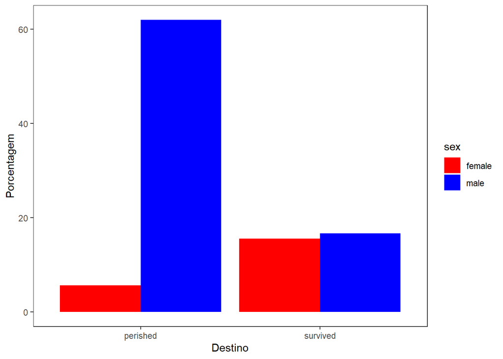

```r
p_11 <- ggplot(titanic, mapping = aes( x = fate, y = percent, fill = sex))
p_11 +
  geom_bar(position = "dodge",
           stat = "identity") +
  theme(legend.position = "top") +
  theme_bw() +
  theme(panel.grid = element_blank()) +
  labs(x = "Destino", y = "Porcentagem") +
  scale_fill_manual(values = c("red", "blue"))
```

Com essa função, como não fazemos nenhum cálculo, podemos plotar algumas coisas interessantes, como por exemplo, colorir valores positivos com uma cor, e negativos com outro

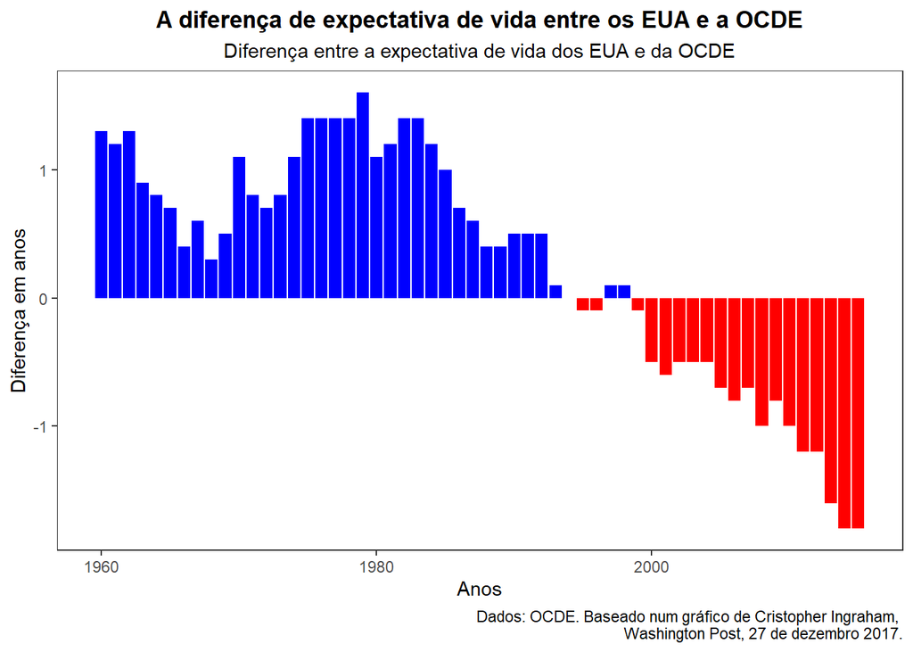

```r
p_12 <- ggplot(data = oecd_sum,
               mapping = aes(x = year,
                             y = diff,
                             fill = hi_lo))
p_12 + geom_col() +
  guides(fill = "none") +
  labs( x = NULL, y = "Diferença em anos",
        title = "A diferença de expectativa de vida entre os EUA e a OCDE",
        subtitle = "Diferença entre a expectativa de vida dos EUA e da OCDE",
        caption = "Dados: OCDE. Baseado num gráfico de Cristopher Ingraham,
        Washington Post, 27 de dezembro 2017.") +
  theme_bw() +
  theme(panel.grid = element_blank(),
        plot.title = element_text(hjust = 0.5, face = "bold"),
        plot.subtitle = element_text(hjust = 0.5)) +
  labs(x = "Anos") +
  scale_fill_manual(values = c("red", "blue"))
```